# Simulation Exercise - Statistical Inference Assignment

Nathaniel Landi

Sunday, September 21, 2014

The exponential distribution can be simulated in R with rexp(n, lambda) where lambda is the rate parameter. The mean of exponential distribution is 1/lambda and the standard deviation is also 1/lambda. In this assignment lambda = 0.2 was set for all of the simulations and the distribution of averages of 40 exponential(0.2)s was investigated. For conclusive result, a thousand or so simulated averages of 40 exponentials was performed

```r
library(ggplot2)

lambda <- 0.2
n_sim <- 1000
samplesize_n <- 40
set.seed(820)

simdata <- data.frame(replicate(n_sim, mean(rexp(samplesize_n,lambda))))
names(simdata) <- c("x")
head(simdata)
```

```
##       x
## 1 5.750
## 2 3.808
## 3 4.058
## 4 3.999
## 5 4.313
## 6 4.418
```

The distribution of sample means is as follows.

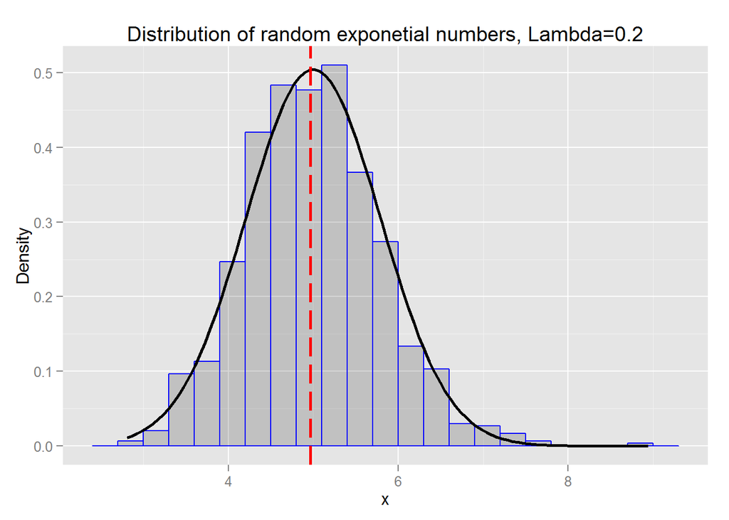

```r
library(ggplot2)
distribution <- ggplot(simdata, aes(x = x)) +
                geom_histogram(alpha = .20,
                               binwidth=.3,
                               colour = "blue",
                               aes(y = ..density..)) +
  stat_function(fun=dnorm,
                size = 1,
                args=list(
                  mean=mean(simdata$x),
                  sd=sd(simdata$x)))+
                  labs(title="Distribution of random exponetial numbers, Lambda=0.2",
                  y="Density") +
                  geom_vline(aes(xintercept=median(x, na.rm=T)),
                             color="red",
                             linetype="longdash",
                             size=1)
print(distribution)
```

The statistics needed to evaluate the distribution were calculated:

Mean:

```r
simmean <- mean(simdata$x)
simmean
```

```
## [1] 4.999
```

Standard Deviation:

```r
simsd <- sd(simdata$x)
simsd
```

```
## [1] 0.7909
```

Variance:

```r
simvar <- var(simdata$x)
simvar
```

```
## [1] 0.6256
```

Expected Mean:

```r
expmean = (1/lambda)
expmean
```

```
## [1] 5
```

Expected Standard Deviation:

```r
expsd = (1/lambda)/sqrt(samplesize_n)
expsd
```

```
## [1] 0.7906
```

Expected Variance:

```r
expvar = ((1/lambda)/sqrt(samplesize_n))^2
expvar
```

```
## [1] 0.625
```

1. The actual simulated mean is very close to the expected mean.
2. Variability of the distibution: Similarly the simulated standard deviation and variances are close to their expected values.

In accordance with the central limit theorem, the sample averages follow a normal distribution and can be seen from the above histogram and theoretical line.

```r
Confidenceinterval <- round((simmean +( c(-1, 1) * 1.96 * simsd / sqrt(length(simdata$x))) ),2)
Confidenceinterval
```

```
## [1] 4.95 5.05
```

The simulation can be run with higher iterations 10000 instead of 1000 to see how the simulated statistic vary from the theoretical expected statistic as a training exercise.